# Practical_O

Gerko Vink

Statistical Programming in R

We use the following packages:

```r
library(plyr)
library(dplyr)
library(magrittr)
library(ggplot2)
```

#### Exercise

1. **Sample 100 samples from a standard normal distribution.**
2. **For each of these samples, calculate the following statistics for the mean:**
- absolute bias
- standard error
- lower bound of the 95% confidence interval
- upper bound of the 95% confidence interval
3. **Create a plot that demonstrates the following**

   *“A replication of the procedure that generates a 95% confidence interval that is centered around the sample mean would cover the population value at least 95 out of 100 times”* (Neyman, 1934)
4. **Present a table containing all simulated samples for which the resulting confidence interval does not contain the population value.**

#### SOLUTION

NB: this is just one of many possible solutions!

We start by fixing the random seed. Otherwise your results will likely vary

```r
set.seed(1234)
```

Then, we draw 100 samples from a standard normal distribution, i.e. a distribution with $\mu=0$ and $\sigma^2=1$, such that for any drawn sample $X$ we could write $X \sim \mathcal{N}(0, 1)$. No specification about the size of the samples is explicitly requested, so for computational reasons a mere 5000 cases would suffice to obtain a detailed approximation.

```r
samples <- lapply(1:100, function(x) rnorm(5000, mean = 0, sd = 1))
```

We use the `lapply()` function to draw the 100 samples and return the resulting output as a list. You could also use a for-loop. Further, we extract the following sources of information for each sample:

- the sample mean $\bar{x}$.
- the absolute bias: i.e. $|\bar{x} - \mu|$, which would be $\bar{x}$ in this case.
- the standard error of the mean: $SE = \sigma/\sqrt{n}$, where $\sigma$ is the known population standard deviation and $n$ is the number of observations in the sample.
- the upper- and lower bounds of the 95% confidence interval about the sample mean:

```r
info <- function(x){
  M <- mean(x)
  DF <- length(x) - 1
  SE <- 1 / sqrt(length(x))
  INT <- qt(.975, DF) * SE
  return(c("Mean"    = M,
           "Bias"    = M - 0,
           "Std.Err" = SE,
           "Lower"   = M - INT,
           "Upper"   = M + INT))
}
```

Then we can compute the info on each of the samples

```r
results <- samples %>% sapply(info) %>% t()
```

Because object `samples` is a list, we can execute funtion `sapply()` to obtain a numerical object with the results of function `info()`. Function $t()$ is here used to obtain the transpose of `sapply()`’s return - the resulting object has all information in the columns.

To create an indicator for the inclusion of the population value $\mu=0$ in the confidence interval, we can add the following coverage column `cov` to the data:

```r
results <- results %>%
  as.data.frame() %>%
  mutate(Covered = Lower < 0 & 0 < Upper)
```

Converting the numerical object to an object of class `data.frame` allows for a more convenient calling of elements. Now we can simply take the column means over dataframe `results` to obtain the average of the estimates returned by `info()`.

```r
colMeans(results)
```

```
##         Mean         Bias      Std.Err        Lower        Upper
##  0.001341244  0.001341244  0.014142136 -0.026383545  0.029066033
##      Covered
##  0.950000000
```

We can see that 95 out of the 100 samples cover the population value.

To identify the samples for which the population value is not covered, we can use column `cov` as it is already a logical evaluation.

```r
noncovered <- results[!results$Covered, ]
```

To create a graph that would serve the purpose of the exercise, one could think about the following graph:

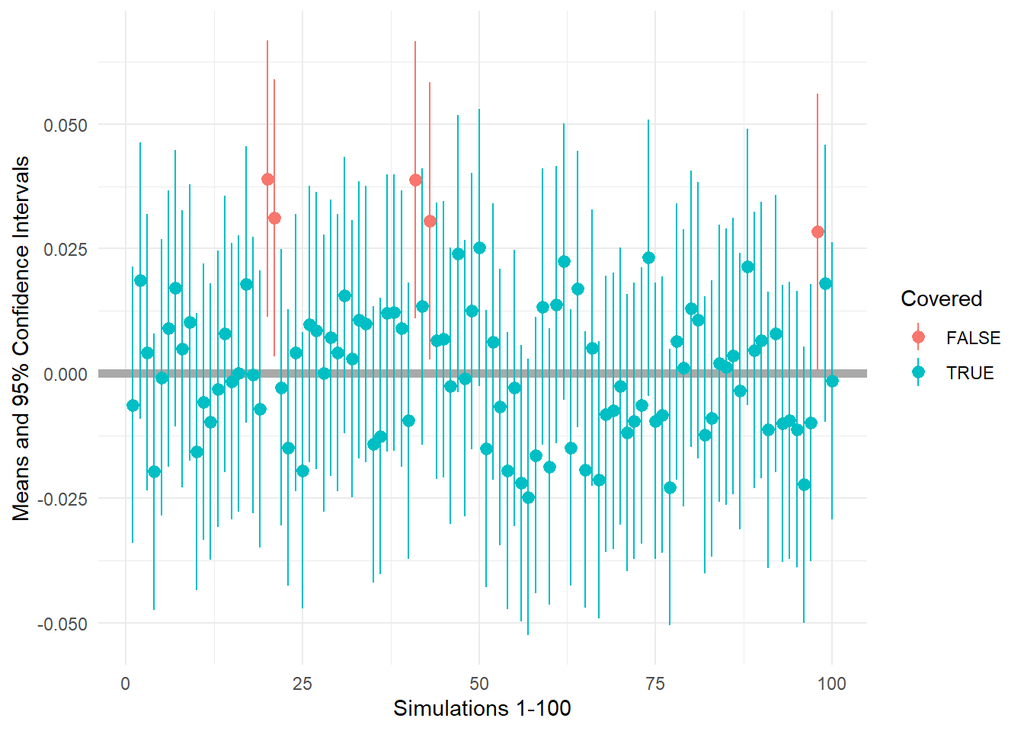

```r
library(ggplot2)

ggplot(results, aes(y = Mean, x = 1:100, ymax = Upper, ymin = Lower,
                    colour = Covered)) +
  geom_hline(yintercept = 0, color = "dark grey", size = 2) +
  geom_pointrange() +
  xlab("Simulations 1-100") +
  ylab("Means and 95% Confidence Intervals") +
  theme_minimal()
```

To just plot the 5 cases that do not overlap with the population parameter:

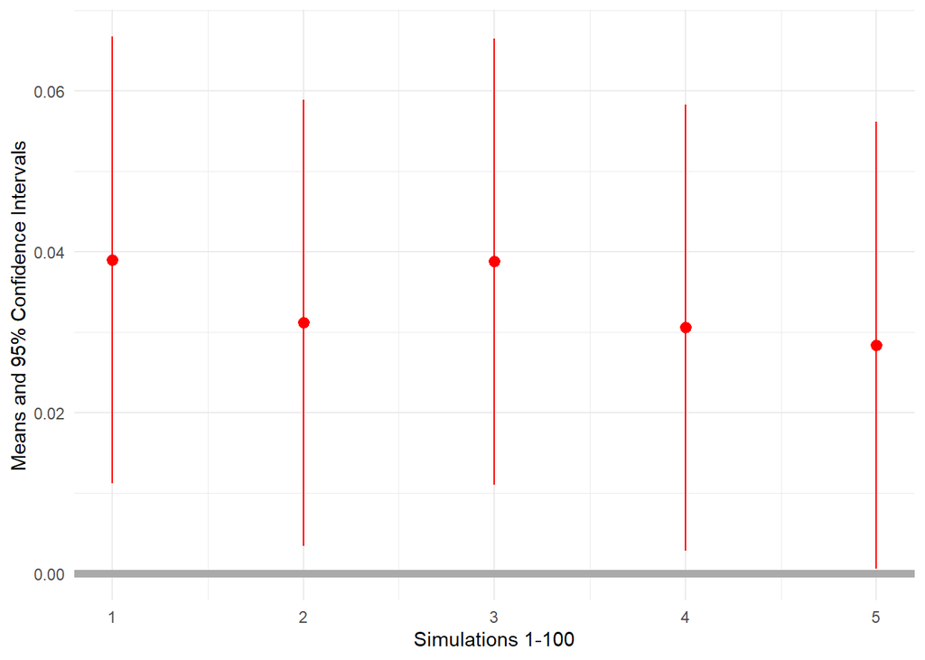

```r
ggplot(noncovered, aes(y = Mean, x = 1:5, ymax = Upper, ymin = Lower)) +
  geom_hline(aes(yintercept = 0), color = "dark grey", size = 2) +
  geom_pointrange(col = "red") +
  xlab("Simulations 1-100") +
  ylab("Means and 95% Confidence Intervals") +
  theme_minimal()
```

End of Practical